# Modeling Morphology

### Female Plots

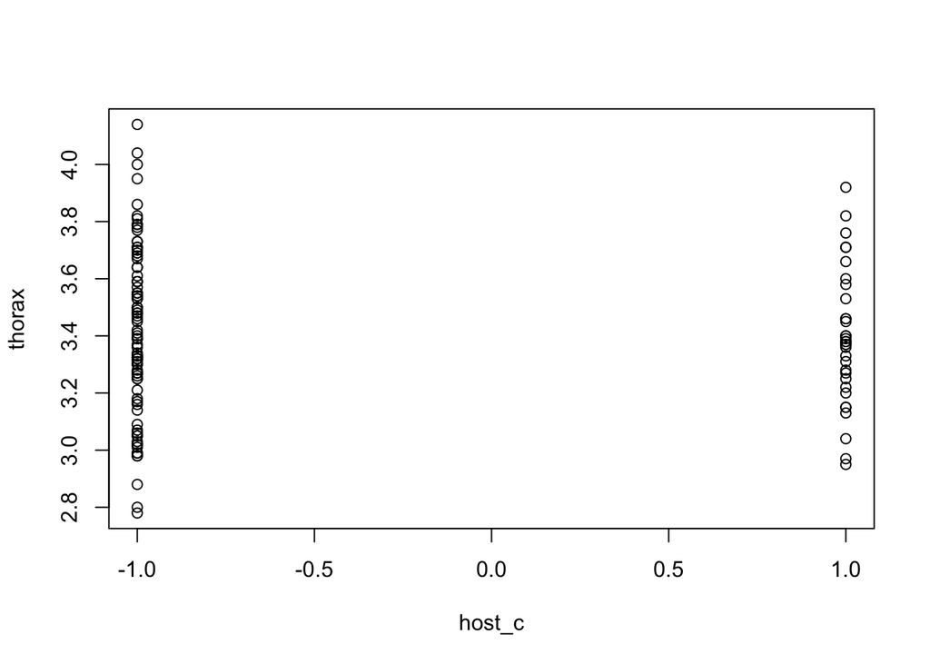

```r
plot(thorax ~ host_c, data=data_fem)
```

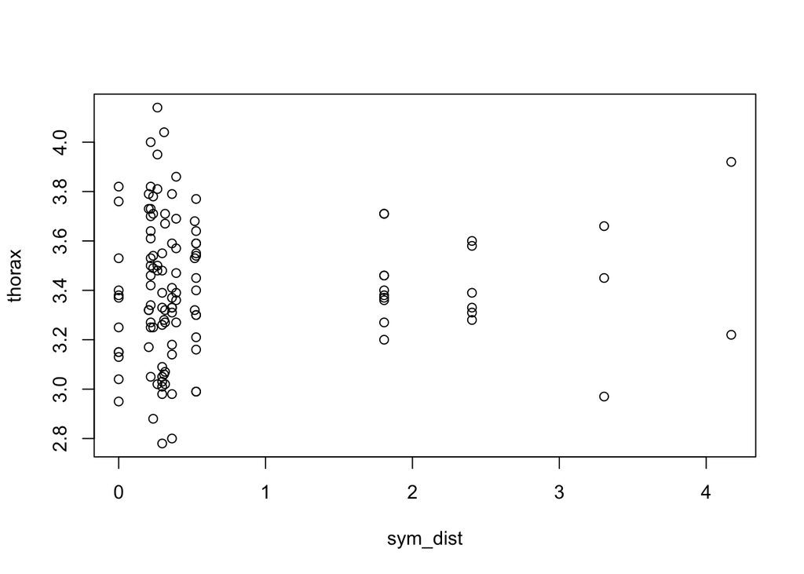

```r
plot(thorax ~ sym_dist, data=data_fem)
```

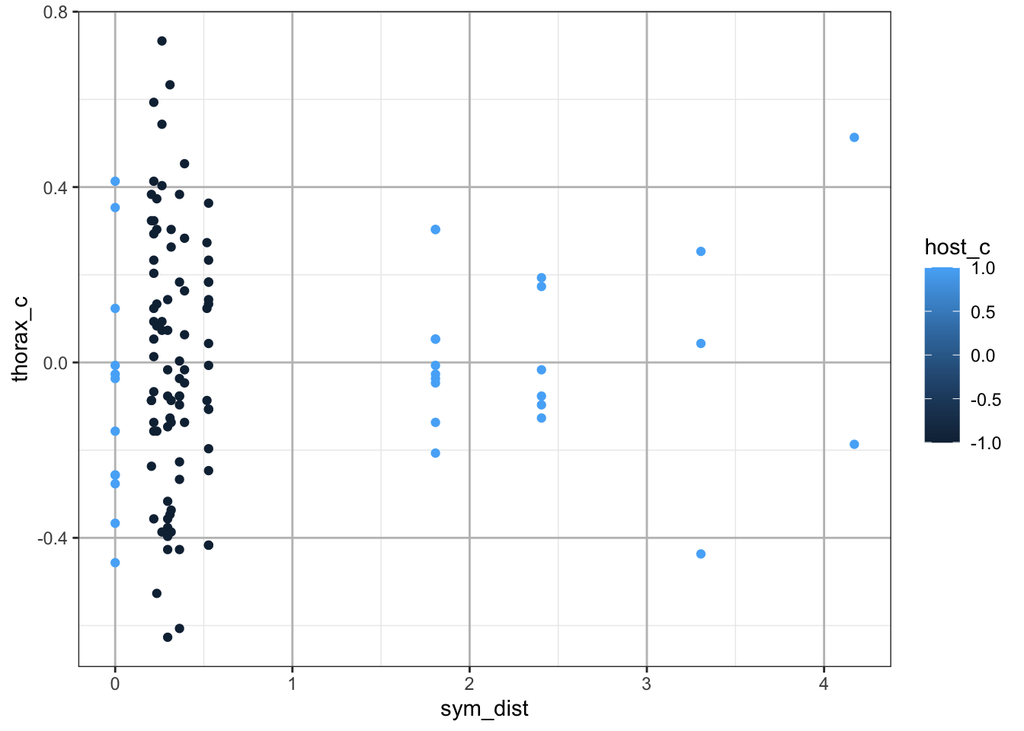

```r
gf_point(thorax_c ~ sym_dist, col=~host_c, data=data_fem)
```

### Male Data

Reading Data

Comparing Models:

- Thorax
- Body
- Wing
- Beak

```r
output_col = FALSE #

data <- read_flight_data("data/all_flight_data-Winter2020.csv")
data_all <- data[[1]]
data_tested <- data[[2]]

data_tested <- data_tested[data_tested$trial_type=="T1",] # only the unique values pulled for those tested
data_tested <- center_data(data_tested)

data_all <- data_all %>%
  filter(trial_type != "T2")
data_all <- center_data(data_all)

data_male <- data_tested[data_tested$sex=="M",]
data_male <- center_data(data_male)
```

#### Comparing Models

**Thorax**

```r
data<-data.frame(R=data_male$thorax_c,
                 A=data_male$host_c,
                 B=data_male$sym_dist)

model_script = paste0(source_path,"generic models-gaussian glmer 2-FF.R")
model_comparisonsAIC(model_script)
```

```
##        [,1]      [,2]
## AICs   -105.2699 -103.276
## models 3         4
## probs  0.7304615 0.2695383
##
## m3   R ~ A + B
## m4   R ~ A * B
```

```r
anova(m3, m4, test="Chisq") # Adding A*B does not improve fit
```

```
## Analysis of Variance Table
##
## Model 1: R ~ A + B
## Model 2: R ~ A * B
##   Res.Df    RSS Df  Sum of Sq Pr(>Chi)
## 1    210 7.3275
## 2    209 7.3273  1 0.00020874   0.9385
```

```r
best.male.thorax <- lm(thorax_c ~ host_c + sym_dist, data=data_male)
tidy_regression(best.male.thorax, is_color=output_col)
```

```
## lm thorax_c ~ host_c + sym_dist data_male
## AIC:  -105.2699
## (Intercept)  coeff:  -0.1354022  Pr(>|t|):  1.098378e-07 *
## host_c       coeff:  -0.1264809  Pr(>|t|):  3.313508e-09 *
## sym_dist     coeff:  0.0901263   Pr(>|t|):  2.083607e-08 *
```

- negative effect of host where if form GRT, the shorter the thorax
- positve effect of sym_dist where the farther from Homestead, the longer the thorax

**Body**

```r
data<-data.frame(R=data_male$body_c,
                 A=data_male$host_c,
                 B=data_male$sym_dist)

model_script = paste0(source_path,"generic models-gaussian glmer 2-FF.R")
model_comparisonsAIC(model_script)
```

```
##        [,1]      [,2]
## AICs   429.3224  430.1409
## models 3         4
## probs  0.6008938 0.3990914
##
## m3   R ~ A + B
## m4   R ~ A * B
```

```r
anova(m3, m4, test="Chisq") # Adding A*B does not improve fit
```

```
## Analysis of Variance Table
##
## Model 1: R ~ A + B
## Model 2: R ~ A * B
##   Res.Df    RSS Df Sum of Sq Pr(>Chi)
## 1    210 90.148
## 2    209 89.649  1   0.49868   0.2809
```

```r
best.male.body <- lm(body_c ~ host_c + sym_dist, data=data_male)
tidy_regression(best.male.body, is_color=output_col)
```

```
## lm body_c ~ host_c + sym_dist data_male
## AIC:  429.3224
## (Intercept)  coeff:  -0.4062525  Pr(>|t|):  4.609688e-06 *
## host_c       coeff:  -0.3672157  Pr(>|t|):  7.089933e-07 *
## sym_dist     coeff:  0.2768821   Pr(>|t|):  7.394263e-07 *
```

- negative effect of host where if from GRT then smaller body
- positive effect of sym_dist where if farther from Homestead then larger body

**Wing**

```r
data<-data.frame(R=data_male$wing_c,
                 A=data_male$host_c,
                 B=data_male$sym_dist,
                 C=data_male$thorax_c)

model_script = paste0(source_path,"generic models-gaussian glmer 3-FF.R")
model_comparisonsAIC(model_script)
```

```
##        [,1]      [,2]      [,3]      [,4]      [,5]       [,6]       [,7]
## AICs   178.3127  179.1819  179.6539  179.7537  180.9264   181.1406   181.1816
## models 3         5         6         10        9          13         7
## probs  0.2498088 0.1617578 0.1277499 0.1215338 0.06761449 0.06074911 0.05951477
##
## m3   R ~ C
## m5   R ~ A + C
## m6   R ~ B + C
## m10  R ~ B * C
## m9   R ~ A * C
## m13  R ~ B * C + A
## m7   R ~ A + B + C
```

```r
anova(m3, m5, test="Chisq") # Adding A does not improve fit
```

```
## Analysis of Variance Table
##
## Model 1: R ~ C
## Model 2: R ~ A + C
##   Res.Df    RSS Df Sum of Sq Pr(>Chi)
## 1    211 28.005
## 2    210 27.857  1   0.14829   0.2904
```

```r
anova(m3, m6, test="Chisq") # Adding B does not improve fit
```

```
## Analysis of Variance Table
##
## Model 1: R ~ C
## Model 2: R ~ B + C
##   Res.Df    RSS Df Sum of Sq Pr(>Chi)
## 1    211 28.005
## 2    210 27.919  1   0.08648   0.4199
```

```r
best.male.wing <- lm(wing_c ~ thorax_c, data=data_male)
tidy_regression(best.male.wing, is_color=output_col)
```

```
## lm wing_c ~ thorax_c data_male
## AIC:  178.3127
## thorax_c     coeff:  2.3197584   Pr(>|t|):  2.956336e-47 *
```

- strong positive effect of thorax where the longer the thorax, the longer the wing

**Beak**

```r
data<-data.frame(R=data_male$beak_c,
                 A=data_male$host_c,
                 B=data_male$sym_dist,
                 C=data_male$thorax_c)

model_script = paste0(source_path,"generic models-gaussian glmer 3-FF.R")
model_comparisonsAIC(model_script)
```

```
##        [,1]      [,2]      [,3]      [,4]     [,5]       [,6]      [,7]
## AICs   88.69349  89.96892  90.04939  90.41733 91.72476   91.99779  92.25941
## models 15        14        11        17       5          9         13
## probs  0.3008093 0.1589773 0.1527075 0.127047 0.06607811 0.0576462 0.05057785
##
## m15  R ~ A * B + B * C
## m14  R ~ A * B + A * C
## m11  R ~ A * B + C
## m17  R ~ A * B + A * C + B * C
## m5   R ~ A + C
## m9   R ~ A * C
## m13  R ~ B * C + A
```

```r
anova(m5, m9, test="Chisq") # adding A*C does not improve fit
```

```
## Analysis of Variance Table
##
## Model 1: R ~ A + C
## Model 2: R ~ A * C
##   Res.Df    RSS Df Sum of Sq Pr(>Chi)
## 1    210 18.476
## 2    209 18.327  1    0.1492   0.1921
```

```r
best.male.beak <- lm(wing_c ~ host_c + thorax_c, data=data_male)
tidy_regression(best.male.beak, is_color=output_col)
```

```
## lm wing_c ~ host_c + thorax_c data_male
## AIC:  179.1819
## (Intercept)  coeff:  0.0137254   Pr(>|t|):  0.6261128
## host_c       coeff:  0.0301393   Pr(>|t|):  0.2915975
## thorax_c     coeff:  2.3437619   Pr(>|t|):  8.107543e-47 *
```

### Male Plots

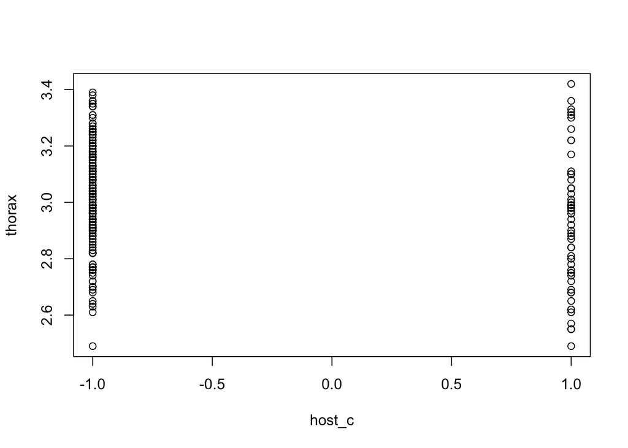

```r
plot(thorax ~ host_c, data=data_male)
```

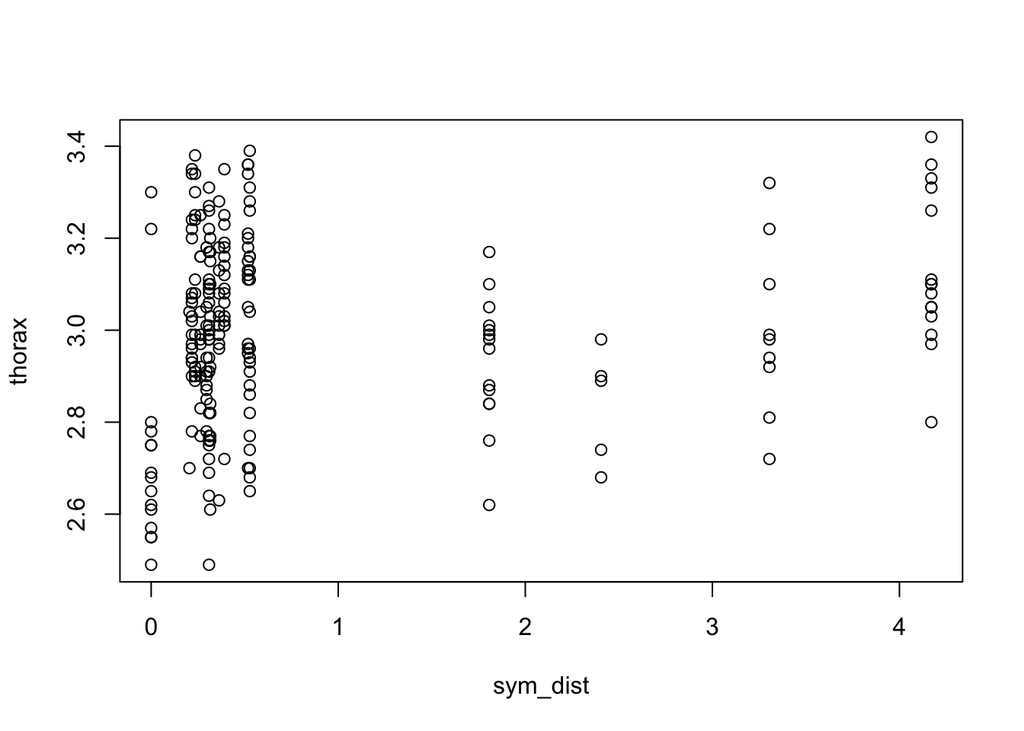

```r
plot(thorax ~ sym_dist, data=data_male)
```

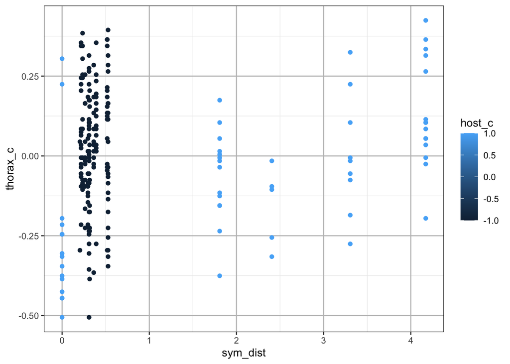

```r
gf_point(thorax_c ~ sym_dist, col=~host_c, data=data_male)
```